# Data manipulation with `dplyr` II

Data Science for Biologists, Spring 2020

Nicholas Paterna

## Instructions

**This assignment must be submitted as an RMarkdown document on Blackboard by *Thursday February 27th at 10:00 am*.**

#### You will be graded on the following criteria:

- Did you enter your name appropriately into the YAML front matter?
- Does the document knit without errors? *Adding `eval=FALSE` to code chunks with errors will not avoid penalty.*
- Does your code in the R chunks have appropriate *comments*?
- Is your submission appropriately *professional*?
  - *You need to run SPELL CHECK before submitting*, available under `Edit->Check Spelling`, **or the ABC icon!!!!!**.
- Do all figures have clean axis labels? (Titles are optional). There should NOT be any underscores in axis labels.
- Did you write your written answers in the answer style?
- Have you addressed the questions as they are asked? Be sure to limit your code and your answers to the scope of the question!
  - If you write code that is not ultimately part of your final answer, you must either: delete it, comment it out, OR move it to a different R chunk with the added chunk options `eval=FALSE, echo=FALSE`.
- Is all work your own, including code and written answers?
  - If ANY of your submitted work is not your own (with the exception of what you have been provided), you will receive a 0 on the assignment. You will be reported for a Level 2 or 3 Academic Integrity Violation, depending on the severity of the issue.

## PREQUEL: DO NOT HARDCODE YOUR PATH TO THE DATA.

Watch in class, I will show you the way!

## Questions

For this lab/assignment, you will be using several datasets that are either built-in to R or an R package, or, is available as a CSV file in the `data/dplyr_lab2/` directory. For these, you’ll need to read in the data to use it. **Read in the CSV files for use at the BEGINNING of the question they are used for.** Once a dataset is read in, you don’t need to read it in again! Seriously, only read in a dataset once (this counts for grading!!) - otherwise you can accidentally introduce bugs, and bugs are bad. Whenever reading in a dataset, you should ALWAYS IMMEDIATELY PRINT THE DATA (tibbles only print 10 rows by default - you can just type the name of the tibble to see these). This allows readers of your reproducible and sharable document to see the data being used!

#### Question 1

Consider the two datasets named `algae_lowtide.csv` and `algae_hightide.csv`. These two datasets contain information about algal abundance measured during experiments carried out under low tide and high tide conditions, respectively. The datasets also contain information about whether there were herbivores (i.e. algae predators!) present.

Create a *single tibble* containing all information from both datasets. Your final tibble should contain three columns:

- tide (should have values “high” and “low”)
- herbivores (should have values “yes” and “no”)
- area (numeric values)

To accomplish this, you will need to manipulate the data using both `mutate()` and `bind_rows()`. Plan how you will do this first, and then implement below. *Your final tibble should be exported to a CSV simply called `algae.csv`*. In addition, if you do NOT print your final tibble, then you WILL LOSE POINTS - **you must ALWAYS LOOK AT YOUR DATA!!!**

```r
## This code chunk should read in, save, print the datasets only
high <- read_csv(paste0(path_to_data, "algae_hightide.csv"))
high
```

```
## # A tibble: 32 x 2
##    herbivores   area
##    <chr>       <dbl>
##  1 no          0.707
##  2 no         25.0
##  3 no         46.6
##  4 no          0.707
##  5 no          5.14
##  6 no          6.18
##  7 no         47.0
##  8 no         22.9
##  9 no         19.4
## 10 no         37.1
## # … with 22 more rows
```

```r
low <- read_csv(paste0(path_to_data, "algae_lowtide.csv"))
low
```

```
## # A tibble: 32 x 2
##    herbivores  area
##    <chr>      <dbl>
##  1 no          9.41
##  2 no         34.5
##  3 no         46.7
##  4 no         16.6
##  5 no         24.4
##  6 no         38.4
##  7 no         33.8
##  8 no         61.1
##  9 no         35.5
## 10 no         46.2
## # … with 22 more rows
```

```r
#Use 'paste0' to attach two strings together without spaces.
```

```r
## This code chunk should perform the analysis, and export the final CSV
low %>%
  mutate(tide = "low") -> low_newtidecol
```

```
## mutate: new variable 'tide' with one unique value and 0% NA
```

```r
low_newtidecol
```

```
## # A tibble: 32 x 3
##    herbivores  area tide
##    <chr>      <dbl> <chr>
##  1 no          9.41 low
##  2 no         34.5  low
##  3 no         46.7  low
##  4 no         16.6  low
##  5 no         24.4  low
##  6 no         38.4  low
##  7 no         33.8  low
##  8 no         61.1  low
##  9 no         35.5  low
## 10 no         46.2  low
## # … with 22 more rows
```

```r
high %>%
  mutate(tide = "high") -> high_newtidecol
```

```
## mutate: new variable 'tide' with one unique value and 0% NA
```

```r
high_newtidecol
```

```
## # A tibble: 32 x 3
##    herbivores   area tide
##    <chr>       <dbl> <chr>
##  1 no          0.707 high
##  2 no         25.0   high
##  3 no         46.6   high
##  4 no          0.707 high
##  5 no          5.14  high
##  6 no          6.18  high
##  7 no         47.0   high
##  8 no         22.9   high
##  9 no         19.4   high
## 10 no         37.1   high
## # … with 22 more rows
```

```r
bind_rows(low_newtidecol, high_newtidecol) -> algae_full
algae_full
```

```
## # A tibble: 64 x 3
##    herbivores  area tide
##    <chr>      <dbl> <chr>
##  1 no          9.41 low
##  2 no         34.5  low
##  3 no         46.7  low
##  4 no         16.6  low
##  5 no         24.4  low
##  6 no         38.4  low
##  7 no         33.8  low
##  8 no         61.1  low
##  9 no         35.5  low
## 10 no         46.2  low
## # … with 54 more rows
```

```r
write_csv(algae_full, paste0(path_to_data, "algae_full.csv"))
```

#### Question 2

Consider the two datasets named `mammals_diet.csv` and `mammals_info.csv`. These two datasets contain information about several different, including their diet, adult average body weight in kg, and the average amount of hours they sleep per night. Read in these two data sets, and then combine them (using the SAME ORDER of arguments each time!) with each of the functions `left_join()`, `right_join()`, `inner_join()`, and finally `anti_join()`. Examine and visually compare their outputs to understand the differences among these functions. Explain *using a markdown bulleted list* the differences among these functions in the space below (short explanations please!). PS: Don’t plagiarize from the documentation. That’s an IAV.

```r
## This code chunk should read in, save, print the datasets only
diet <- read_csv(paste0(path_to_data, "mammals_diet.csv"))
diet
```

```
## # A tibble: 4 x 3
##   name                           order        diet
##   <chr>                          <chr>        <chr>
## 1 Patas monkey                   Primates     omnivore
## 2 Thirteen-lined ground squirrel Rodentia     herbivore
## 3 Lesser short-tailed shrew      Soricomorpha omnivore
## 4 Baboon                         Primates     omnivore
```

```r
info <- read_csv(paste0(path_to_data, "mammals_info.csv"))
info
```

```
## # A tibble: 4 x 4
##   name                           order     sleep_hours bodywt_kg
##   <chr>                          <chr>           <dbl>     <dbl>
## 1 Patas monkey                   Primates         10.9    10
## 2 Thirteen-lined ground squirrel Rodentia         13.8     0.101
## 3 Domestic cat                   Carnivora        12.5     3.3
## 4 Baboon                         Primates          9.4    25.2
```

```r
## perform joins here, and print the output to compare!
inner_join(diet, info)
```

```
##             > rows only in x  (1)
##             > rows only in y  (1)
##             > matched rows     3
##             >                 ===
##             > rows total       3
```

```
## # A tibble: 3 x 5
##   name                           order    diet      sleep_hours bodywt_kg
##   <chr>                          <chr>    <chr>           <dbl>     <dbl>
## 1 Patas monkey                   Primates omnivore         10.9    10
## 2 Thirteen-lined ground squirrel Rodentia herbivore        13.8     0.101
## 3 Baboon                         Primates omnivore          9.4    25.2
```

```r
left_join(diet, info)
```

```
##            > rows only in x   1
##            > rows only in y  (1)
##            > matched rows     3
##            >                 ===
##            > rows total       4
```

```
## # A tibble: 4 x 5
##   name                           order        diet      sleep_hours bodywt_kg
##   <chr>                          <chr>        <chr>           <dbl>     <dbl>
## 1 Patas monkey                   Primates     omnivore         10.9    10
## 2 Thirteen-lined ground squirrel Rodentia     herbivore        13.8     0.101
## 3 Lesser short-tailed shrew      Soricomorpha omnivore         NA      NA
## 4 Baboon                         Primates     omnivore          9.4    25.2
```

```r
right_join(diet, info)
```

```
##             > rows only in x  (1)
##             > rows only in y   1
##             > matched rows     3
##             >                 ===
##             > rows total       4
```

```
## # A tibble: 4 x 5
##   name                           order     diet      sleep_hours bodywt_kg
##   <chr>                          <chr>     <chr>           <dbl>     <dbl>
## 1 Patas monkey                   Primates  omnivore         10.9    10
## 2 Thirteen-lined ground squirrel Rodentia  herbivore        13.8     0.101
## 3 Domestic cat                   Carnivora <NA>             12.5     3.3
## 4 Baboon                         Primates  omnivore          9.4    25.2
```

```r
anti_join(diet, info)
```

```
##            > rows only in x   1
##            > rows only in y  (1)
##            > matched rows    (3)
##            >                 ===
##            > rows total       1
```

```
## # A tibble: 1 x 3
##   name                      order        diet
##   <chr>                     <chr>        <chr>
## 1 Lesser short-tailed shrew Soricomorpha omnivore
```

#### Question 3

Now, consider the additional dataset named `diets_foods.csv` which gives some example foods that different “vores” might eat. Combine this dataset with the previous other two mammal datasets to *create the largest table possible (i.e. with the most number of mammals) that DOES NOT contain NAs.* There may be multiple versions of this solution (in terms of table w/ most number of rows), but only give one. Your final output must be ordered based ascending body weights.

```r
## This code chunk should read in, save, print the dataset only
dietfoods <- read_csv(paste0(path_to_data, "diets_foods.csv"))
dietfoods
```

```
## # A tibble: 3 x 2
##   diet      food
##   <chr>     <chr>
## 1 carnivore meat
## 2 herbivore leaves
## 3 omnivore  all_the_noms
```

```r
## perform tasks here
inner_join(info, diet) %>%
  inner_join(dietfoods) %>%
  arrange(bodywt_kg)
```

```
##             > rows only in x  (1)
##             > rows only in y  (1)
##             > matched rows     3
##             >                 ===
##             > rows total       3
##             > rows only in x  (0)
##             > rows only in y  (1)
##             > matched rows     3
##             >                 ===
##             > rows total       3
```

```
## # A tibble: 3 x 6
##   name                        order    sleep_hours bodywt_kg diet     food
##   <chr>                       <chr>          <dbl>     <dbl> <chr>    <chr>
## 1 Thirteen-lined ground squi… Rodentia        13.8     0.101 herbivo… leaves
## 2 Patas monkey                Primates        10.9    10     omnivore all_the_n…
## 3 Baboon                      Primates         9.4    25.2   omnivore all_the_n…
```

#### Question 4

This question will consider the `ggplot2` dataset (it’s built-in to the library and loaded already!) called `msleep` which, you guessed it, is what I used to make questions 2-3. This dataset contains many missing values. Examine the dataset visually with `View()` from the console to get a full sense. We’ll use this dataset to practice working with missing data in a variety of ways.

- Create **four** new versions of this data, each one saved to a new variable of its own *with a meaningful name*! The new versions should be as follows (each is independent; don’t “build” instructions on top of each other). Be sure to use `dplyr` command(s)!!
  1. All rows with NA are removed, using `drop_na()`.
  2. All rows with NA in the `conservation` column ONLY are removed, using `drop_na()`. The result will still have NA’s, just not in this column.
  3. All rows with NA in the `brainwt` column ONLY are removed, using `drop_na()`. The result will still have NA’s, just not in this column.
  4. All NAs in the column `brainwt` are replaced with the number 0, using `replace_na()`. (But think: should you ever actually do this in real data analysis? ..NO.)

Be sure to print the output for each new version!

```r
## define the FOUR new data frames here
drop_na(msleep) -> dropped_dataset
```

```
## drop_na: removed 63 rows (76%), 20 rows remaining
```

```r
head(dropped_dataset)
```

```
## # A tibble: 6 x 11
##   name  genus vore  order conservation sleep_total sleep_rem sleep_cycle awake
##   <chr> <chr> <chr> <chr> <chr>              <dbl>     <dbl>       <dbl> <dbl>
## 1 Grea… Blar… omni  Sori… lc                  14.9       2.3       0.133   9.1
## 2 Cow   Bos   herbi Arti… domesticated         4         0.7       0.667  20
## 3 Dog   Canis carni Carn… domesticated        10.1       2.9       0.333  13.9
## 4 Guin… Cavis herbi Rode… domesticated         9.4       0.8       0.217  14.6
## 5 Chin… Chin… herbi Rode… domesticated        12.5       1.5       0.117  11.5
## 6 Less… Cryp… omni  Sori… lc                   9.1       1.4       0.15   14.9
## # … with 2 more variables: brainwt <dbl>, bodywt <dbl>
```

```r
msleep %>%
  drop_na(conservation) -> dropped_conservation
```

```
## drop_na: removed 29 rows (35%), 54 rows remaining
```

```r
head(dropped_conservation)
```

```
## # A tibble: 6 x 11
##   name  genus vore  order conservation sleep_total sleep_rem sleep_cycle awake
##   <chr> <chr> <chr> <chr> <chr>              <dbl>     <dbl>       <dbl> <dbl>
## 1 Chee… Acin… carni Carn… lc                  12.1      NA        NA      11.9
## 2 Moun… Aplo… herbi Rode… nt                  14.4       2.4      NA       9.6
## 3 Grea… Blar… omni  Sori… lc                  14.9       2.3       0.133   9.1
## 4 Cow   Bos   herbi Arti… domesticated         4         0.7       0.667  20
## 5 Nort… Call… carni Carn… vu                   8.7       1.4       0.383  15.3
## 6 Dog   Canis carni Carn… domesticated        10.1       2.9       0.333  13.9
## # … with 2 more variables: brainwt <dbl>, bodywt <dbl>
```

```r
msleep %>%
  drop_na(brainwt) -> dropped_brain
```

```
## drop_na: removed 27 rows (33%), 56 rows remaining
```

```r
head(dropped_brain)
```

```
## # A tibble: 6 x 11
##   name  genus vore  order conservation sleep_total sleep_rem sleep_cycle awake
##   <chr> <chr> <chr> <chr> <chr>              <dbl>     <dbl>       <dbl> <dbl>
## 1 Owl … Aotus omni  Prim… <NA>                17         1.8      NA       7
## 2 Grea… Blar… omni  Sori… lc                  14.9       2.3       0.133   9.1
## 3 Cow   Bos   herbi Arti… domesticated         4         0.7       0.667  20
## 4 Dog   Canis carni Carn… domesticated        10.1       2.9       0.333  13.9
## 5 Roe … Capr… herbi Arti… lc                   3        NA        NA      21
## 6 Goat  Capri herbi Arti… lc                   5.3       0.6      NA      18.7
## # … with 2 more variables: brainwt <dbl>, bodywt <dbl>
```

```r
msleep %>%
  replace_na(list(brainwt = 0)) -> zero_brain
```

```
## replace_na: changed 27 values (33%) of 'brainwt' (27 fewer NA)
```

```r
head(zero_brain)
```

```
## # A tibble: 6 x 11
##   name  genus vore  order conservation sleep_total sleep_rem sleep_cycle awake
##   <chr> <chr> <chr> <chr> <chr>              <dbl>     <dbl>       <dbl> <dbl>
## 1 Chee… Acin… carni Carn… lc                  12.1      NA        NA      11.9
## 2 Owl … Aotus omni  Prim… <NA>                17         1.8      NA       7
## 3 Moun… Aplo… herbi Rode… nt                  14.4       2.4      NA       9.6
## 4 Grea… Blar… omni  Sori… lc                  14.9       2.3       0.133   9.1
## 5 Cow   Bos   herbi Arti… domesticated         4         0.7       0.667  20
## 6 Thre… Brad… herbi Pilo… <NA>                14.4       2.2       0.767   9.6
## # … with 2 more variables: brainwt <dbl>, bodywt <dbl>
```

Then, for each version AND the original untouched `msleep`, calculate the mean brain weight (`brainwt` - NOT BODY WEIGHT!) using simply `mean(dataframe$column-with-weight)`. For the original untouched version, calculate the mean TWICE: once as usual, and once with the added argument `na.rm=TRUE` provided to `mean()`.

```r
## calculate the SIX means here (read directions to know what this means - one for each new dataset, and two for the original)
dropped_dataset %>%
  summarize(avg_brainwt = mean(brainwt))
```

```
## summarize: now one row and one column, ungrouped
```

```
## # A tibble: 1 x 1
##   avg_brainwt
##         <dbl>
## 1      0.0788
```

```r
dropped_conservation %>%
  summarize(avg_brainwt = mean(brainwt))
```

```
## summarize: now one row and one column, ungrouped
```

```
## # A tibble: 1 x 1
##   avg_brainwt
##         <dbl>
## 1          NA
```

```r
dropped_brain %>%
  summarize(avg_brainwt = mean(brainwt))
```

```
## summarize: now one row and one column, ungrouped
```

```
## # A tibble: 1 x 1
##   avg_brainwt
##         <dbl>
## 1       0.282
```

```r
zero_brain %>%
  summarize(avg_brainwt = mean(brainwt))
```

```
## summarize: now one row and one column, ungrouped
```

```
## # A tibble: 1 x 1
##   avg_brainwt
##         <dbl>
## 1       0.190
```

```r
msleep %>%
  summarize(avg_brainwt = mean(brainwt))
```

```
## summarize: now one row and one column, ungrouped
```

```
## # A tibble: 1 x 1
##   avg_brainwt
##         <dbl>
## 1          NA
```

```r
msleep %>%
  summarize(avg_brainwt = mean(na.rm = TRUE, brainwt))
```

```
## summarize: now one row and one column, ungrouped
```

```
## # A tibble: 1 x 1
##   avg_brainwt
##         <dbl>
## 1       0.282
```

**Compare your outputs** - are they all the same? Which one(s) is(are) correct? Below, explain briefly which one(s) give(s) the right answer, and why the wrong ones are wrong. **This can/should be a bulleted list.**

### Answer (Q4):

#### Question 5

For this question, we’ll work with conditional mutation using the dataset `pima.csv`, which contains information about Pima Native women in the North American southwest who, as a population, tend to have elevated rates of Type II Diabetes.

```r
## read in, save, print dataset here
pima <- read_csv(paste0(path_to_data, "pima.csv"))
pima
```

```
## # A tibble: 752 x 9
##    npreg glucose   dbp  skin insulin   bmi pedigree   age diabetic
##    <dbl>   <dbl> <dbl> <dbl>   <dbl> <dbl>    <dbl> <dbl> <chr>
##  1     6     148    72    35       0  33.6    0.627    50 Yes
##  2     1      85    66    29       0  26.6    0.351    31 No
##  3     8     183    64     0       0  23.3    0.672    32 Yes
##  4     1      89    66    23      94  28.1    0.167    21 No
##  5     0     137    40    35     168  43.1    2.29     33 Yes
##  6     5     116    74     0       0  25.6    0.201    30 No
##  7     3      78    50    32      88  31      0.248    26 Yes
##  8    10     115     0     0       0  35.3    0.134    29 No
##  9     2     197    70    45     543  30.5    0.158    53 Yes
## 10     4     110    92     0       0  37.6    0.191    30 No
## # … with 742 more rows
```

- Create a new column called `glucose_status` using the functions `mutate()` and `case_when()` that recodes `glucose` into levels “low” (<= 70), “average” (>70, <=120), “above-average” (>120, <=160), and “high” (>160). Save your result to a new variable and print the output to confirm. **HINT!!** You may need to refer back to the intro lab to remind yourself about `&`.

```r
# wrangle
pima %>%
  mutate(glucose_status =
           case_when(glucose <= 70 ~ "low",
                     glucose >70 & glucose <= 120 ~ "average",
                     glucose >120 & glucose <=160 ~ "above-average",
                     glucose >160 ~ "high")) -> glucose_scale
```

```
## mutate: new variable 'glucose_status' with 4 unique values and 0% NA
```

```r
head(glucose_scale)
```

```
## # A tibble: 6 x 10
##   npreg glucose   dbp  skin insulin   bmi pedigree   age diabetic glucose_status
##   <dbl>   <dbl> <dbl> <dbl>   <dbl> <dbl>    <dbl> <dbl> <chr>    <chr>
## 1     6     148    72    35       0  33.6    0.627    50 Yes      above-average
## 2     1      85    66    29       0  26.6    0.351    31 No       average
## 3     8     183    64     0       0  23.3    0.672    32 Yes      high
## 4     1      89    66    23      94  28.1    0.167    21 No       average
## 5     0     137    40    35     168  43.1    2.29     33 Yes      above-average
## 6     5     116    74     0       0  25.6    0.201    30 No       average
```

- Visualize the relationship between your new column `glucose_status` and `diabetic`. Hint: how can we see TWO categorical variables in one plot? You’ve done this before! It’s a barplot! **Make sure it is DODGED** and not stacked. **Importantly** when you first make this plot it will likely have undesirable visual features. To fix this, read over [this documentation](https://ggplot2.tidyverse.org/reference/position_dodge.html) and find the solution to implement here (2nd plot from the top).

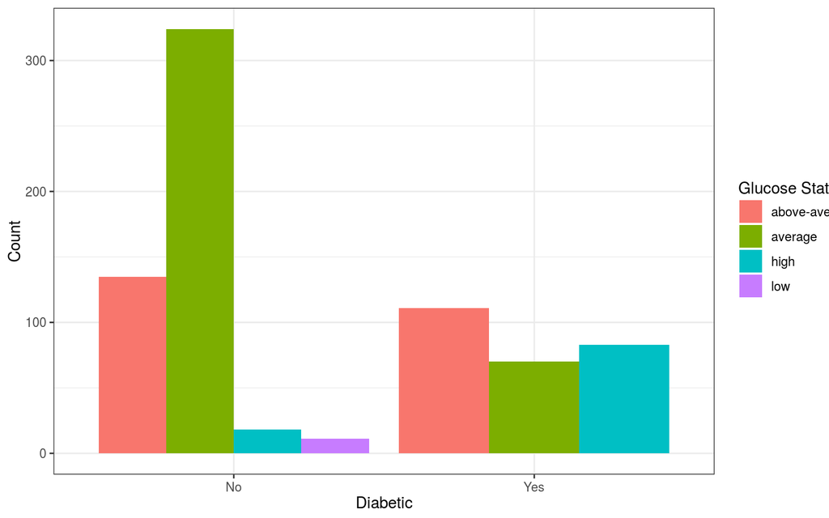

```r
# your plot! make it nice!
glucose_scale %>%
  ggplot(aes(x = diabetic, fill = glucose_status)) +
  geom_bar(position = "dodge") +
  labs(x = "Diabetic", y = "Count", fill = "Glucose Status")
```

- Use `if_else()` and `mutate()` to create a new column called “pregnant” to say “Yes” if the individual ever was pregant, and “No” if the individual never had a pregnancy. Save the output for subsequent use.

```r
#ifelse
pima %>%
  mutate(pregnant = if_else(npreg >0, "Yes", "No")) -> pregnancy
```

```
## mutate: new variable 'pregnant' with 2 unique values and 0% NA
```

```r
head(pregnancy)
```

```
## # A tibble: 6 x 10
##   npreg glucose   dbp  skin insulin   bmi pedigree   age diabetic pregnant
##   <dbl>   <dbl> <dbl> <dbl>   <dbl> <dbl>    <dbl> <dbl> <chr>    <chr>
## 1     6     148    72    35       0  33.6    0.627    50 Yes      Yes
## 2     1      85    66    29       0  26.6    0.351    31 No       Yes
## 3     8     183    64     0       0  23.3    0.672    32 Yes      Yes
## 4     1      89    66    23      94  28.1    0.167    21 No       Yes
## 5     0     137    40    35     168  43.1    2.29     33 Yes      No
## 6     5     116    74     0       0  25.6    0.201    30 No       Yes
```

- Check that your new pregnant variable is correct by wrting code to reveal: Is the sum of npreg for all rows where pregnant is “No” 0? If this is true, it worked! This can be done entirely with `dplyr` commands. This is how one might write an assertion - ask if this condition is true, and if not, the script should die. For an added challenge, actually write an assertion in the code chunk (to this end, check out the function `dplyr::pull()`. Super useful.)

```r
## check here
pregnancy %>%
  filter(pregnant == "No") %>%
  summarize(sum(npreg))
```

```
## filter: removed 644 rows (86%), 108 rows remaining
```

```
## summarize: now one row and one column, ungrouped
```

```
## # A tibble: 1 x 1
##   `sum(npreg)`
##          <dbl>
## 1            0
```

```r
## Pull function isolates a column from the dataset and creates an individual array. Using pull here an assertion is created, this checks to make sure I performed the task I wanted.

## An assertion is NOT ALWAYS a pull.

pregnancy %>%
  filter(pregnant == "No") %>%
  summarize(sumpreg = sum(npreg)) %>%
  pull(sumpreg)
```

```
## filter: removed 644 rows (86%), 108 rows remaining
## summarize: now one row and one column, ungrouped
```

```
## [1] 0
```

- From the original dataset, *replace* the column `diabetic` with a new version that says `TRUE` and `FALSE` instead of Yes and No. Do this in two ways: with `if_else()` and with `case_when()`. Be careful not to actually overwrite the original version of the data itself!!

```r
# solution with if_else
pima %>%
  mutate(diabetic =
         if_else(diabetic == "Yes", "TRUE", "FALSE")) -> diabetic_if
```

```
## mutate: changed 752 values (100%) of 'diabetic' (0 new NA)
```

```r
head(diabetic_if)
```

```
## # A tibble: 6 x 9
##   npreg glucose   dbp  skin insulin   bmi pedigree   age diabetic
##   <dbl>   <dbl> <dbl> <dbl>   <dbl> <dbl>    <dbl> <dbl> <chr>
## 1     6     148    72    35       0  33.6    0.627    50 TRUE
## 2     1      85    66    29       0  26.6    0.351    31 FALSE
## 3     8     183    64     0       0  23.3    0.672    32 TRUE
## 4     1      89    66    23      94  28.1    0.167    21 FALSE
## 5     0     137    40    35     168  43.1    2.29     33 TRUE
## 6     5     116    74     0       0  25.6    0.201    30 FALSE
```

```r
# solution with case_when
pima %>%
  mutate(diabetic =
           case_when(diabetic == "Yes" ~ "TRUE",
                     diabetic == "No" ~ "FALSE")) -> diabetic_case
```

```
## mutate: changed 752 values (100%) of 'diabetic' (0 new NA)
```

```r
head(diabetic_case)
```

```
## # A tibble: 6 x 9
##   npreg glucose   dbp  skin insulin   bmi pedigree   age diabetic
##   <dbl>   <dbl> <dbl> <dbl>   <dbl> <dbl>    <dbl> <dbl> <chr>
## 1     6     148    72    35       0  33.6    0.627    50 TRUE
## 2     1      85    66    29       0  26.6    0.351    31 FALSE
## 3     8     183    64     0       0  23.3    0.672    32 TRUE
## 4     1      89    66    23      94  28.1    0.167    21 FALSE
## 5     0     137    40    35     168  43.1    2.29     33 TRUE
## 6     5     116    74     0       0  25.6    0.201    30 FALSE
```

#### Question 6

The `chickwts` dataset (built-in to base R) contains information on the weight of chicks after being fed different feed supplements. The different feed supplements are labeled casein, horsebean, linseed, meatmeal, soybean, and sunflower in the `feed` column. I have created a new dataset in `feed_protein.csv` that contains the grams of protein per cup for each of these feeds.

```r
## look at chickwts, read/save/look at the external data set here
chicks <- read_csv(paste0(path_to_data, "feed_protein.csv"))
head(chicks)
```

```
## # A tibble: 6 x 2
##   feed_type g_protein
##   <chr>         <dbl>
## 1 horsebean        13
## 2 linseed          31
## 3 soybean          29
## 4 sunflower        33
## 5 meatmeal         22
## 6 casein          160
```

Using your `dplyr` functions, combine the two data-frames so that there is an additional `g_protein` column and all of the original columns and rows in chickwts are retained (but don’t overwrite anything! save it to something else!). Hint: you’ll need to make sure the datasets are compatible before you can join them (check out `dplyr::rename()` and be sure to specify arguments in the right order!). **For another bonus**, write an assertion to check that the final data frame contains at least TWO correct components, and do NOT DO ANY HARDCODING!!! You will not lose points for a bad assertion here, just don’t leave any majors bugs behind you.

```r
## wrangle it here
bigchicks <- chickwts
chicks %>%
  rename(feed = feed_type) %>%
  full_join(by = "feed", bigchicks, chicks) -> final_chicks
```

```
## rename: renamed one variable (feed)
```

```
## full_join: added one column (weight)
```

```
##            > rows only in x    0
```

```
##            > rows only in y    0
```

```
##            > matched rows     71    (includes duplicates)
```

```
##            >                 ====
```

```
##            > rows total       71
```

```r
head(final_chicks)
```

```
## # A tibble: 6 x 3
##   feed      g_protein weight
##   <chr>         <dbl>  <dbl>
## 1 horsebean        13    179
## 2 horsebean        13    160
## 3 horsebean        13    136
## 4 horsebean        13    227
## 5 horsebean        13    217
## 6 horsebean        13    168
```

```r
## HERE's HOW to think about this assertion:
# for the answer to be right, we know there needs to be three columns:
correct_ncol <- 3
if (ncol(final_chicks) != correct_ncol)
{
  stop("You have too many columns!")
}

if (ncol(final_chicks) == correct_ncol)
  {
    print("Good job, you have three columns!")
  }
```

```
## [1] "Good job, you have three columns!"
```

Finally, make a visualization (specifically a scatterplot) showing the relationship between *median* chicken weight across nutritional content (measured as grams of protein per cup). Each point should be additionally labeled with the name of its corresponding feed. First, do this with `geom_point()` and `geom_text()` (don’t spend much time here, the punchline is the next task - style the figure appropriately but don’t try to “fix” it - you’ll see what I mean). OMG another hint!! Summarize will remove unnecessary columns from your data too. To re-get those columns, either: a) also group by them (IF IT MAKES SENSE), or b) you’ll need to use some join magic.

```
## group_by: 2 grouping variables (feed, g_protein)
```

```
## summarize: now 6 rows and 3 columns, one group variable remaining (feed)
```

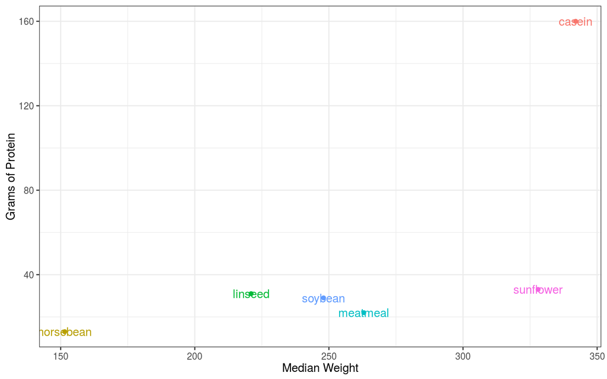

```r
### version of plot with point/text
final_chicks %>%
  group_by(feed, g_protein) %>%
  summarize(med_weight = median(weight))%>%
  ggplot(aes(x = med_weight, y = g_protein)) +
  geom_point(aes(color = feed)) +
  geom_text(aes(label = feed, color = feed)) +
  labs(x = "Median Weight", y = "Grams of Protein") +
  theme(legend.position = "NONE")
```

Now, feel disappointed in the viz and feel thrilled to learn about the library [`ggrepel`](https://cran.r-project.org/web/packages/ggrepel/vignettes/ggrepel.html). (GO OVER THE POST! GO OVER THE POST! The word ggrepel back there is a LINK!) Load this library in the setup chunk (not here!), and use it below to make an updated version of the figure but instead of `geom_text()`, use EITHER `geom_text_repel()` or `geom_label_repel()` - your choice! Ensure a compelling and attractive figure (to the extent possible with this data..)

```
## group_by: 2 grouping variables (feed, g_protein)
```

```
## summarize: now 6 rows and 3 columns, one group variable remaining (feed)
```

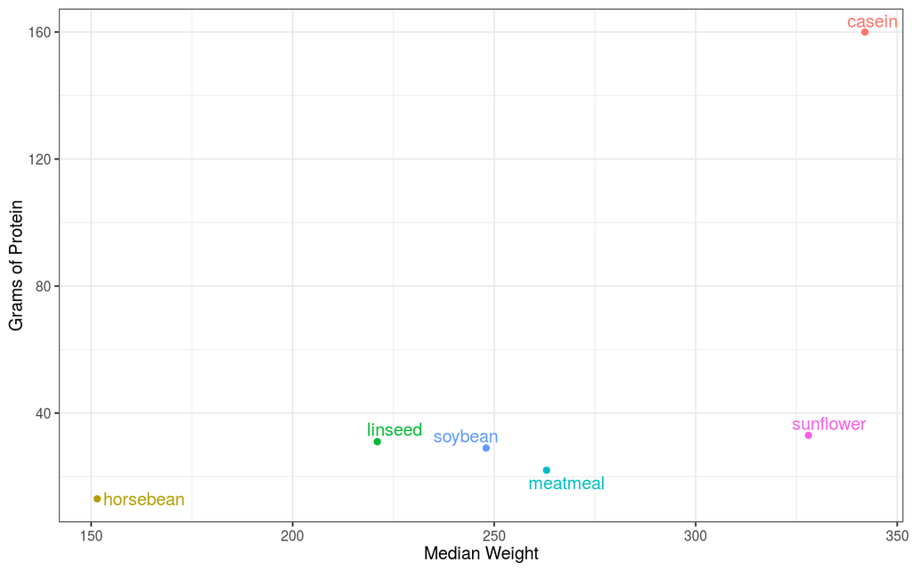

```r
###fig using ggrepel
final_chicks %>%
  group_by(feed, g_protein) %>%
  summarize(med_weight = median(weight))%>%
  ggplot(aes(x = med_weight, y = g_protein)) +
  geom_point(aes(color = feed)) +
  geom_text_repel(aes(label = feed, color = feed)) +
  labs(x = "Median Weight", y = "Grams of Protein") +
  theme(legend.position = "NONE")
```

##### Question 7 (Bonus Question)

One more big one and you’re done! (Un)happily, this question uses *all the skillz*. For this question, you will using data from the `nycflights13` library (pre-loaded in the setup chunk). There are five datasets from this package, and we will focus on the two `flights` and `planes`. Examine these using `View()` from the console (not in this Rmarkdown!).

`flights` contains information about individual departures. Individual planes are indicated by their tail number (`tailnum`). Information about individual planes is available in the data `planes`. In particular, this tibble lists the year each individual plane was manufactured. From `flights` and `planes`, make a combined tibble that contains the following columns:

- tail number
- year of manufacture for each plane.
- month of departure
- mean air time for each plane at each month basis (HINT! does this exist already or do you to make it? You have to make it. Sounds like a grouping and summarizing to me, just saying.)

You should ONLY CONSIDER planes that flew to LAX (`dest`) in summer months June, July, and August (`month`). Once you have created your beautifully wrangled data, make a scatterplot of mean arrival delay across year of manufacture, )

Consider best-plotting principles and choose your own stylstic adventure. In 1-2 sentences below, describe trends you observe, or fail to observe as the case may be!

HINTS AND RULES:

- Wrangle hints/rules:
  - First subset and wrangle each of the two data frames to only the columns/rows of interest. Then join together the subsetted versions. When joining, you should do so by ONLY CONSIDERING the info shared by both tibbles (which join is this?)
  - Do NOT hardcode months or destination of LAX when you filter!!!!! Predefine what destination, months you are interested in and then use them in your code
  - For months, don’t forget `%in%`!
  - Remember - the only shared names between dataframes you want to join should be the names you want to join by. This is important!!! Hint2: year in `flights` is NOT the same as year in `planes`.
  - Are your means being funky? Did you apply your new question 4 knowledge? Definitely not a great idea to keep around NA’s **in the `arr_time` column specifically.**
  - All wrangling should be in a SINGLE PIPE! Do not even attempt to write this all at once. Write one line at a time, check it, and then keep tacking on the pipes.
  - For your plot, you will months to be their NAMES not NUMBERS! This involves…recoding your data using your new conditional mutation skills during the wrangling stage! (You can hardcode month names for this recoding.)
- Plot hints/rules:
  - Summer months should be clearly distinguished through faceting, and color if you wish - but NOT THE DEFAULT COLORS!
  - Make sure there is a separate trend line for each month. The line should be NOT be curvy! Straight line!
  - Make sure the trend lines are black and NOT the same color as the points
  - Appropriate labels and all that jazz

```r
### wrangle here
flights %>%
  filter(month %in% c("6", "7", "8")) %>%
  filter(dest == "LAX") %>%
  select(tailnum, month, air_time, dest) -> summertime
```

```
## filter: removed 249,781 rows (74%), 86,995 rows remaining
```

```
## filter: removed 82,560 rows (95%), 4,435 rows remaining
```

```
## select: dropped 15 variables (year, day, dep_time, sched_dep_time, dep_delay, …)
```

```r
head(summertime)
```

```
## # A tibble: 6 x 4
##   tailnum month air_time dest
##   <chr>   <int>    <dbl> <chr>
## 1 N33132      6      330 LAX
## 2 N12218      6      329 LAX
## 3 N789JB      6      333 LAX
## 4 N704X       6      320 LAX
## 5 N641VA      6      322 LAX
## 6 N338AA      6      327 LAX
```

```r
planes %>%
  select(tailnum, year) -> manu_info
```

```
## select: dropped 7 variables (type, manufacturer, model, engines, seats, …)
```

```r
head(manu_info)
```

```
## # A tibble: 6 x 2
##   tailnum  year
##   <chr>   <int>
## 1 N10156   2004
## 2 N102UW   1998
## 3 N103US   1999
## 4 N104UW   1999
## 5 N10575   2002
## 6 N105UW   1999
```

```r
inner_join(summertime, manu_info) -> joined_flights
```

```
## inner_join: added one column (year)
```

```
##             > rows only in x  (  168)
```

```
##             > rows only in y  (2,708)
```

```
##             > matched rows     4,267
```

```
##             >                 =======
```

```
##             > rows total       4,267
```

```r
head(joined_flights)
```

```
## # A tibble: 6 x 5
##   tailnum month air_time dest   year
##   <chr>   <int>    <dbl> <chr> <int>
## 1 N33132      6      330 LAX    1998
## 2 N12218      6      329 LAX    1998
## 3 N789JB      6      333 LAX    2011
## 4 N704X       6      320 LAX    1997
## 5 N641VA      6      322 LAX    2008
## 6 N338AA      6      327 LAX    1987
```

```r
joined_flights %>%
  drop_na() %>%
  group_by(month, tailnum, year) %>%
  summarize(avg_airtime = mean(air_time)) -> question_7
```

```
## drop_na: removed 44 rows (1%), 4,223 rows remaining
```

```
## group_by: 3 grouping variables (month, tailnum, year)
```

```
## summarize: now 1,245 rows and 4 columns, 2 group variables remaining (month, tailnum)
```

```r
head(question_7)
```

```
## # A tibble: 6 x 4
## # Groups:   month, tailnum [6]
##   month tailnum  year avg_airtime
##   <int> <chr>   <int>       <dbl>
## 1     6 N11206   2000        327
## 2     6 N1201P   1998        313
## 3     6 N12109   1994        323
## 4     6 N12114   1995        318.
## 5     6 N12116   1996        308
## 6     6 N12125   1998        320
```

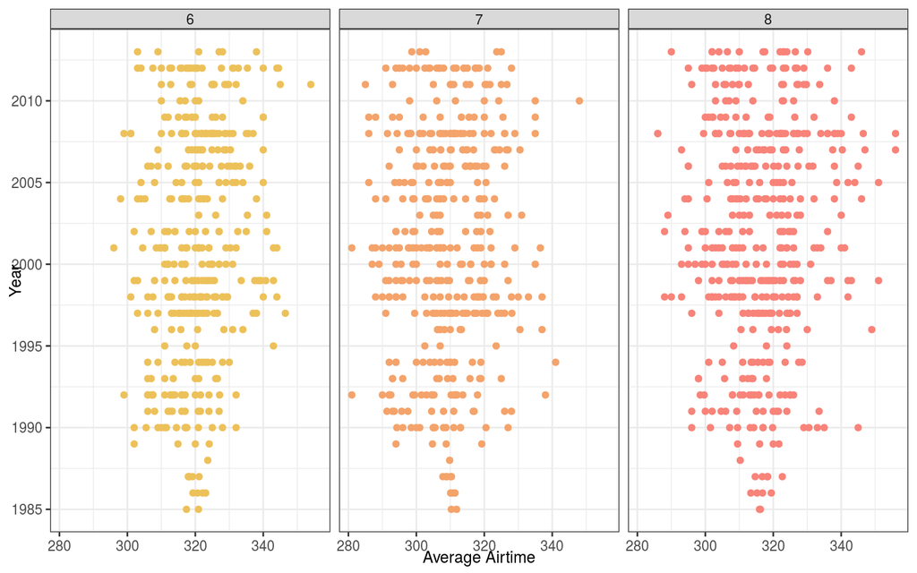

```r
## r code to plot goes here
question_7 %>%
  ggplot(aes(x = avg_airtime, y = year)) +
  geom_point(aes(color = month)) +
  scale_color_gradient(low = "#edc15a", high = "#f88379") +
  facet_grid(~ month) +
  labs(x = "Average Airtime", y = "Year") +
  theme(legend.position = "NONE",
        axis.title = element_text(size = 10))
```

**For an absolutely ridiculous bonus**, use emojis instead of points. [See this vignette](https://cran.r-project.org/web/packages/emojifont/vignettes/emojifont.html). Note: This package is already installed in the cloud but it is not loaded. Please make sure to use only the most absurd emoji(s) for your points.

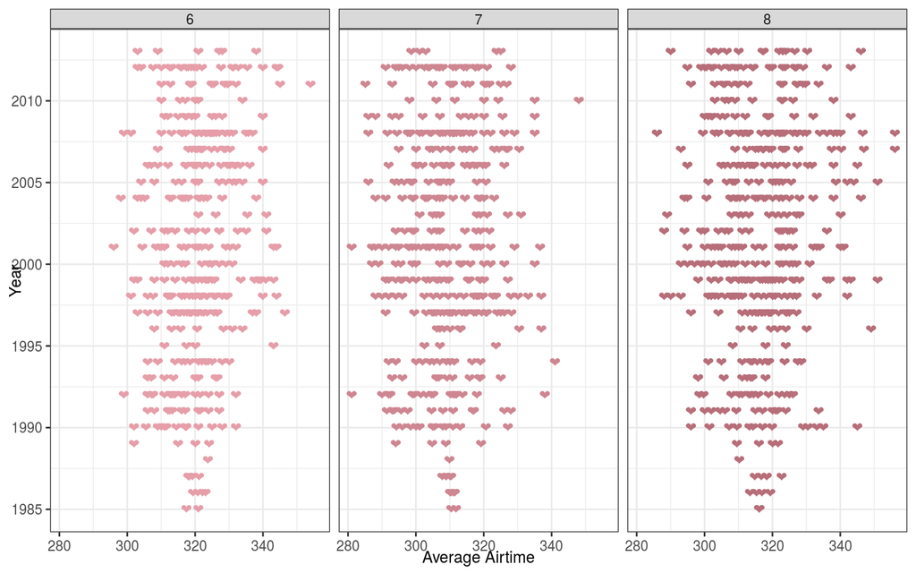

```r
### emoji plot
question_7 %>%
  ggplot(aes(x = avg_airtime, y = year, color = month)) +
  geom_text(label = emoji('heart'), size = 3, replace = TRUE) +
  scale_color_gradient(low = "#e69ea9", high = "#b76e79") +
  facet_grid(~ month) +
  labs(x = "Average Airtime", y = "Year") +
  theme(legend.position = "NONE",
        axis.title = element_text(size = 10))
```